# Understanding Intake and Outcome Patterns in the Long Beach Animal Shelter

Authors

Helen Peng

Aditi Srivastava

Macy Liang-Jones

Sueah Kim

Published

December 8, 2025

## Introduction

Cities across the United States face growing challenges in managing animal intake, shelter capacity, and ensuring positive outcomes for lost or abandoned pets. In order to optimize the allocation of resources and design better outreach programs, we must understand where these animals are coming from, why they enter the system, and how these patterns vary across different neighbourhoods.

This project investigates several demographic and location-driven patterns in the Long Beach Animal Shelter dataset. By combining spatial mapping, temporal analysis, and categorical comparisons, we aim to reveal meaningful patterns that can guide improvements in shelter resource allocation and outcome prediction. Ultimately, the motivation for this analysis is to understand how shelters can use administrative data to improve real-world welfare outcomes for animals and the communities that care for them.

In the following report, we investigate four key research questions using observations from Long Beach Animal Shelter data. This data comes from TidyTuesday’s online repository, originally sourced from City of Long Beach Animal Care Services. The dataset features a record of real animal intake cases, including 22 variables helpful in our analyses of four questions. Because the data captures both spatial and behavioral patterns of animal intakes, it allows us to uncover meaningful trends in intakes and outcomes.

Each row is one record of an animal being taken into the Long Beach shelter. Each column is a piece of information on the animal, including both demographic information (such as sex and date of birth), intake information (such as intake condition and type), outcome information (such as outcome type and date) and geographic information (such as latitude and longitude). In total, the dataset contains over 29,787 observations of animal intakes across Long Beach from Jan 1, 2017 to December 31, 2024.

Below, we outline the four research questions that guide our analysis.

1. How do animal intakes/jurisdiction vary geographically, and are there identifiable spatial clusters?
2. Do animal intake patterns in Long Beach show meaningful seasonal or long-term temporal trends?
3. Do intake circumstances or time spent in shelters present trends for case outcomes?
4. What demographic patterns and naming trends can be observed in the shelter’s animal population?

## Graphs & Findings

### 1. How do animal intakes/jurisdiction vary geographically and are there identifiable spatial clusters?

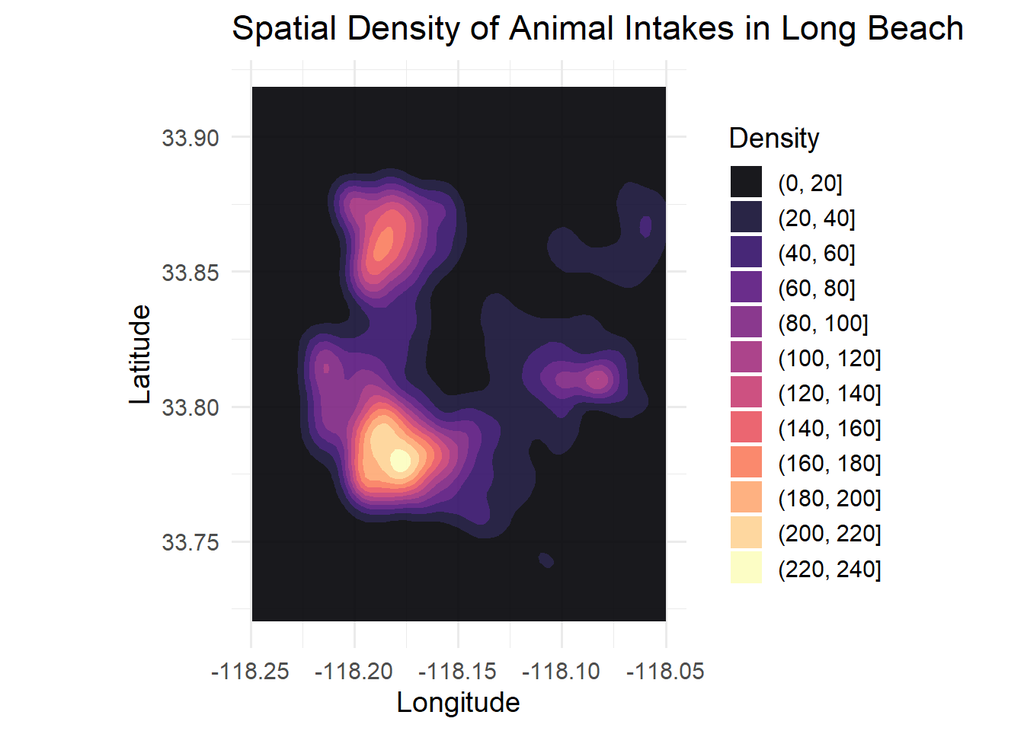

We wanted to learn about how animal intakes vary geographically across Long Beach and whether identifiable spatial clusters exist. This suggests we should examine latitude and longitude, the two variables encoding the exact location of each animal intake. By mapping these points using a spatial density plot, we can visualize where intakes are concentrated and whether specific neighborhoods contribute disproportionately to the amount of animal intakes. To complement this spatial analysis, we use a Multidimensional Scaling (MDS) map to examine whether jurisdictions, the regions responsible for different intake cases, show distinct structural patterns in the types or characteristics of animals entering the shelter.

The density map reveals clear spatial clustering in animal intakes across Long Beach, and several key patterns show up. First, high-density clusters appear in central and western Long Beach. The lightest colors (reds, oranges, yellows) indicate the highest intake density, and these light colours are seen near -118.20 longitude and 33.78-33.80 latitude. These clusters likely correspond to more urban, high-population neighborhoods where more stray or lost animals are reported. Moderate clusters spread outward into surrounding areas. Near the lighter coloured clusters are purple regions showing moderate intake density, suggesting steady but lower rates of animals entering the shelter. Low-density regions appear at the southern and far-eastern edges. These areas likely reflect less residential activity, fewer stray animals, or fewer calls to animal control.

Overall, the shape of the density distribution suggests intake cases are not random. Instead, they form geographic clusters, which may correlate with population density, neighborhood characteristics (housing type, income levels, etc.), availability of outdoor spaces where animals may roam, and variation in reporting rates across jurisdictions. The spatial density map suggests that animal intakes in Long Beach are highly concentrated in specific neighborhoods rather than evenly distributed across the city. Identifying these clusters can help City Animal Care Services allocate field officers more efficiently, prioritize outreach, and target prevention efforts in the areas where they are most needed.

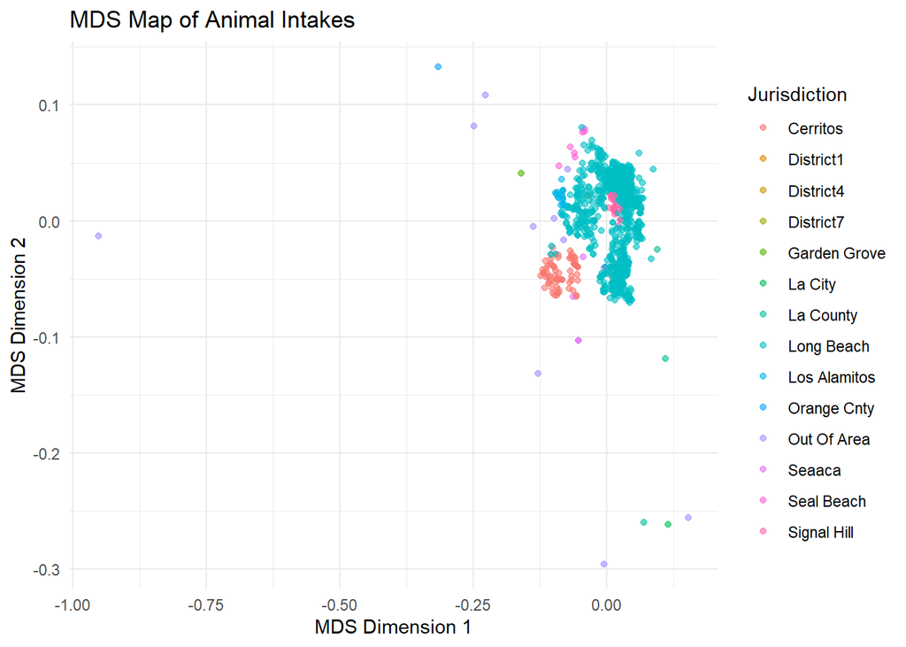

The MDS map provides a complementary perspective by examining how jurisdictions differ in their intake characteristics. Most jurisdictions, especially Long Beach, which accounts for the majority of cases, form a tight, central cluster, indicating that their intake profiles are highly similar. Smaller surrounding jurisdictions such as Seal Beach and Los Alamitos partially overlap this main cluster, suggesting broadly comparable intake patterns with mild variations. In contrast, Cerritos forms a noticeably distinct cluster, meaning its intake cases differ more systematically from the rest, potentially reflecting differences in species composition, intake reasons, or demographic distribution. The “Out of Area” category shows the widest spread across the MDS space, indicating extremely heterogeneous intake patterns that do not align clearly with any single jurisdiction. This likely reflects the fact that Out-of-Area cases originate from many unrelated contexts.

These insights strengthen the evidence that animal intake is shaped by local conditions rather than being uniformly distributed, highlighting opportunities for more targeted interventions and outreach.

### 2. Do animal intake patterns in Long Beach show meaningful seasonal or long-term temporal trends?

To answer this question, we first plotted monthly intake counts to examine broad temporal patterns:

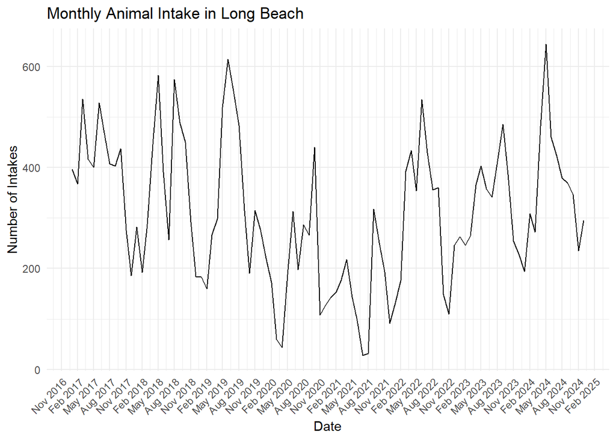

From visual inspection of the monthly time series, a clear repeating annual pattern emerges. Intakes consistently peak in the late spring and summer months (approximately April–August) and decline in the winter (December–February). These warm-season surges align with common shelter dynamics such as increased animal roaming during longer daylight hours, “kitten season,” and higher owner surrenders associated with summer moves and housing transitions. This seasonal cycle appears in nearly every year of data, even though total intake volume varies across years.

To more formally separate seasonal and long-term structure, we applied STL decomposition:

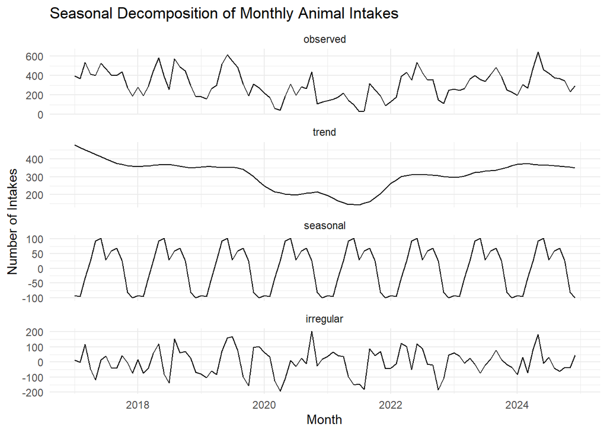

The decomposition confirms the clear annual cycle seen in the raw data. The seasonal component shows a stable, repeating pattern aligned with the observed spring–summer peaks. The trend component also highlights a pronounced dip around 2020–2021—likely linked to pandemic-related disruptions—followed by a gradual recovery. By the end of the series, overall intake levels return to roughly their pre-pandemic baseline, suggesting that the long-term intake environment has normalized rather than fundamentally shifted.

### 3. Do intake circumstances or time spent in shelters present trends for case outcomes?

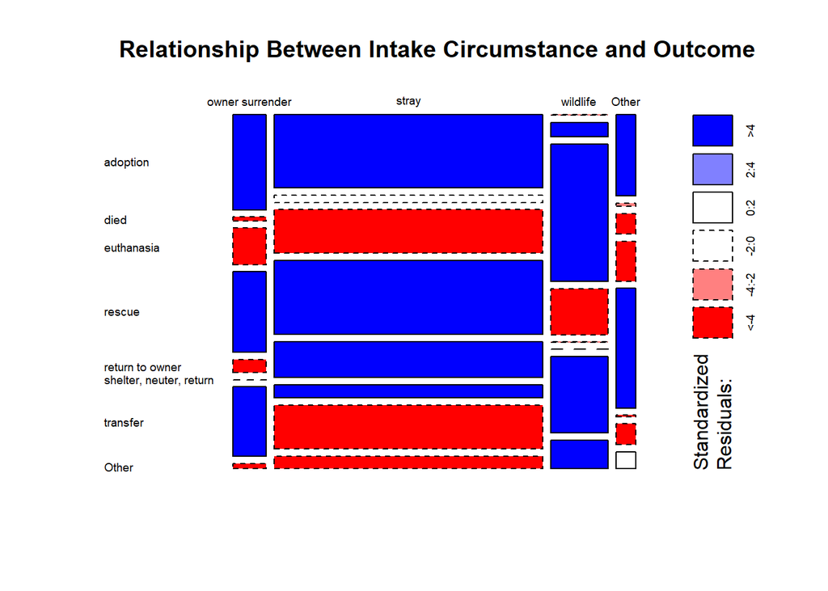

These many results have some implications on broad trends affecting intake and outcome. First, as is the mission with many animal shelters, there is a strong effort to push adoption of stray and surrendered animals, which is backed by the evidence. The outcomes indicate that these patterns are significant statistically. It also follows an animal shelter’s role that many surrendered animals have less negative outcomes than by chance, like death or euthanasia; they also are not returned to owners. These patterns are also substantiated statistically. The distinction between wildlife and “pet” trends are also apparent, with wildlife more commonly transferred, dying, or put under euthanasia. So, there are clear trends between the circumstances for an animal’s intake and the eventual outcome, many of which reflect the role and priorities of the shelter itself.

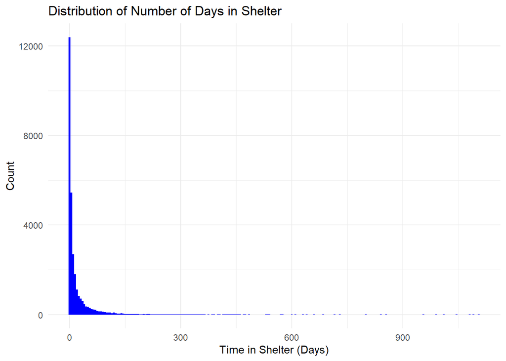

Another interesting factor that might mediate the relationship between intake circumstances and outcomes is the number of days an animal spends in the shelter. Looking at the distribution, it is highly skewed, with a vast proportion of stays less than 75 days but with some outliers stretching into the 900+ day mark. For the sake of this analysis, we will focus on the data points between 0 and 200 days.

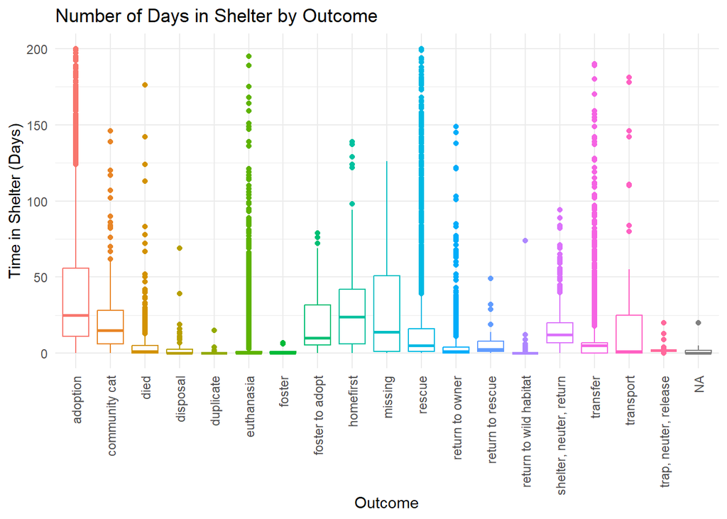

By analyzing the side-by-side boxplots of time in shelter for each outcome, we can observe some trends that reflect shelter policies and roles. For example, there were very low central tendencies and spreads for euthanasia and trap, neuter, release, which indicates the performance of a prescribed procedure with little delay. There was a higher median value for adoption, indicating those animals that were held in shelters under hope of adoption for extended periods of time. The number of high outlier values for euthanasia likely reflects the reality that many animals are held onto for hope of adoption, but eventually put under euthanasia because of resource strain. Return to owner and return to wild habitat similarly had very low central tendencies and spreads; those cases had a prescribed action that removed the animals from the care of the shelter, so there was little need to keep animals for longer. An ANOVA to assess the significance of these findings would have been valuable. However, we noticed that the model assumptions were not met; the residuals were not normally distributed with a Q-Q plot. So, we are limited to weaker visual analysis.

### 4. What demographic patterns and naming trends can be observed in the shelter’s animal population?

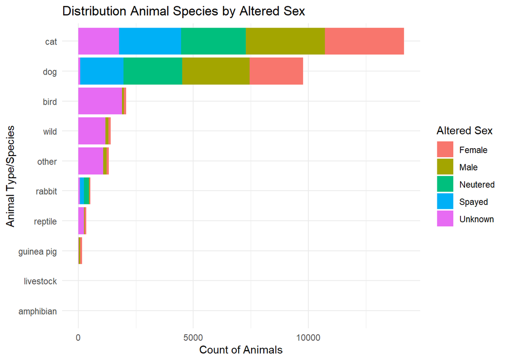

```
--- Contingency Table (animal_type vs. sex) ---
```

```
                    Female Male Neutered Spayed Unknown
  Bird                  98   77        0      0    1900
  Cat                 3434 3431     2812   2699    1769
  Dog                 2315 2929     2559   1888      77
  Reptile/Amphibian     61   30        0      0     256
  Small Mammal         111  108      216    176      87
  Wildlife/Other       211  279        1      0    2263
```

```
    Pearson's Chi-squared test

data:  contingency_table
X-squared = 16256, df = 20, p-value < 2.2e-16
```

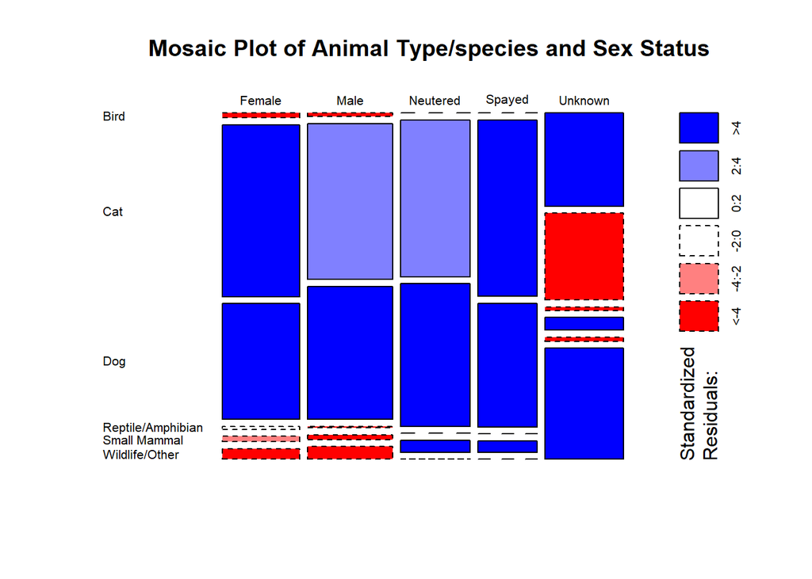

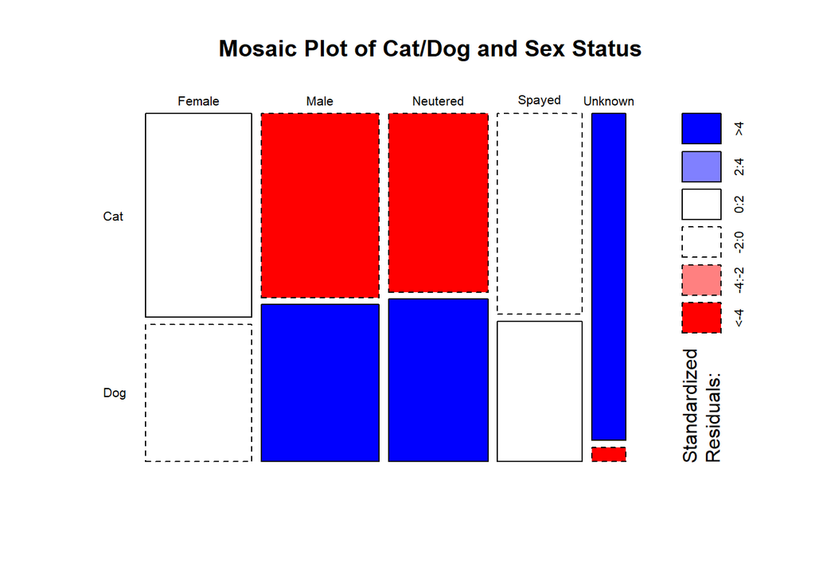

The mosaic plot visually confirms the dependencies identified by the Chi-squared test, indicating where the observed counts differ from the expected counts that would exist if the two variables were not associated.

As indicated in our contingency table and in the full mosaic plot, cats and dogs are the majority of the shelters population, so we take a look at a smaller mosaic plot that focuses on this majority. From the mosaic plot of only cats and dogs vs sex statuses, we find that cats are highly underrepresented in the male and neutered columns while dogs are highly overrepresented in these columns. Additionally, cats are highly overrepresnted in the unknown column and dogs are highly underrepresented in this columns.

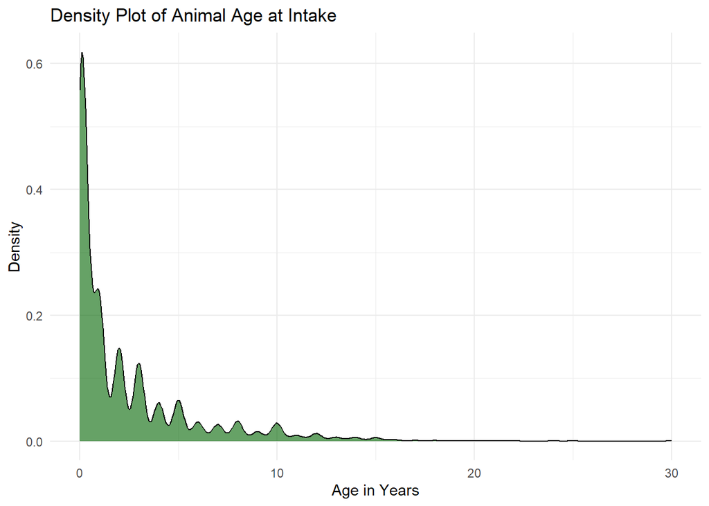

The density plot of age at intagke provides a clear picture of the age structure of shelters’s population. The distribution is heavily skewed right, with a large peak for age very close to zero years. This indicates that the majority of the animals entering the shelter are very young, most likely recently born. This pattern is typical of many shelters and suggests high rates of unplanned breading in the community which is the largest contributor to the shelter. The presence of smaller peaks after 1 year suggests a much smaller, but still present, intake of adult animals which is likely due to the less common practice of giving away a pet after raising it, however not impossible.

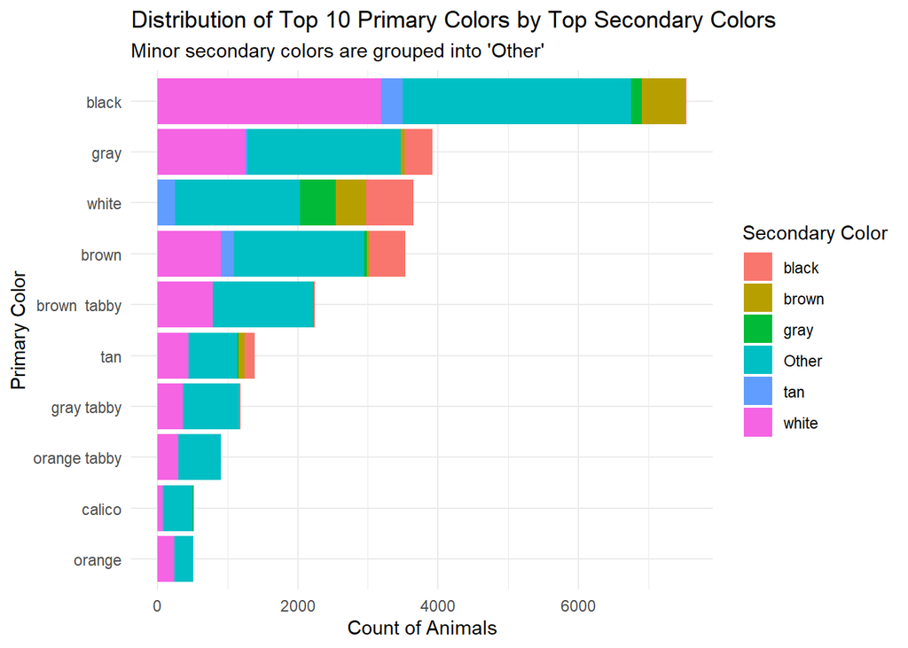

This stacked bar chart details the color characteristics of the shelter population, which often relates to breed trends and owner preference. Black is the most common primary color, followed by Gray and White which reflect the common coat colors in pets. Furthermore, the ‘Other’ secondary color group accounts of the largest proportion of animals for each primary colors, suggesting that animals are wither single colored or exhibit a wide variety of less common secondary coloring. A secondary color of ‘White’ is also very common across all primary colors, indicating that a mix of white and another predominant color is common in pets. This information can be useful for identification and providing descriptions of physical appeaser for animals awaiting adoption.

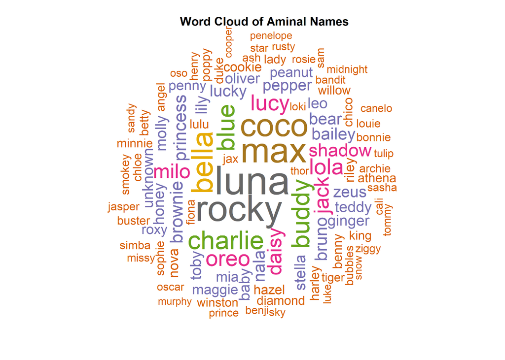

We are interested in what naming trends can be observed in the shelter’s animal population. To answer this question we create a word cloud of animal names. From the plot we find that the most popular names, indicated by there large font size, are Luna, Rocky, CoCo, Max, Bella, Charlie, and Buddy. These names are short, simple, and align with popular trends for pets. The frequent use of these common names suggests that owners generally follow established cultural norms rather than selecting highly unique or descriptive names for their pets.

It is also important to note that some animals were named by shelter staff rather than previous owners, which may further contribute to the naming similarities seen in the data. This pattern highlights how both owner preferences and shelter practices shape the naming trends and conventions, connecting the human side of pet ownership to the data at hand.

The analysis of the shelter’s population reveals a clear set of demographic patterns, physical characteristics, and naming conventions. Demographically, the shelter is defined by the predominantly young age of animals and the statistically significant imbalance in sex status by species. Furthermore, the population’s physical traits are highly consistent, with the analusis indicating that the animals are dominated by common coat colors. Ultimately, Understanding these patterns across age, sex, and color helps the shelter more accurately characterize its adoptable animals and better meet the needs of potential adopters.

## Conclusion

Using a TidyTuesday dataset of Long Beach Animal Shelter cases, we examined the following four research questions: How do animal intakes/jurisdiction vary geographically and are there identifiable spatial clusters? Do animal intake patterns in Long Beach show meaningful seasonal or long-term temporal trends? Do intake circumstances or time spent in shelters present trends for case outcomes? What demographic patterns and naming trends can be observed in the shelter’s animal population?

We examined the role of geographic factors in cases by looking at spatial density, connecting intake circumstances to rural-urban distinctions. We also used MDS mapping to notice jurisdiction-specific patterns that underlie intake circumstances, identifying the heterogeneity of intake factors across jurisdiction labels. By looking at seasonal decompositions and time series data, we noticed time-dependent patterns that reflected global events and annual trends. Using a mosaic plot, we determined intake circumstances and outcome combinations that were positively or negatively correlated, using Pearson residuals. By examining the distribution of the number of days at the shelter, fully and then conditioned on outcome, we determined patterns that align with the shelter’s goals and priorities.

## Future Work

While our analyses reveal several clear spatial, temporal, and demographic patterns in Long Beach animal intakes, they also raise questions that we were not able to fully address within the scope of this project. A key limitation of our work is that we mainly analyze shelter records in isolation, without linking them to neighbourhood-level socioeconomic information (e.g., household income or housing density). Future work could merge this dataset with census or city planning data to examine whether areas with higher intake density correspond to particular demographic characteristics or resource gaps, which would provide more targeted guidance for outreach and prevention efforts.

Future work could also incorporate external environmental and socioeconomic data, such as stray animal reports, access to veterinary services, and housing stability, to better understand the drivers behind high-intake regions. Linking shelter data with census tracts or city-level infrastructure (parks, major roads, multi-unit housing) would allow for a more predictive spatial model rather than purely descriptive mapping.

Additionally, future work could include logistic regressions to model the probability of adoption, euthanisia or transfer as a function of intake condition when adjusting for age, jurisdiction, and animal type. This would help us explore uncertainty probabilities in more depth. Finally, future work could examine intake conditions in more detail by assessing whether certain conditions and illnesses are geographically clustered. This could involve formal hypothesis testing to determine whether observed patterns differ significantly across jurisdictions or over time. Overall, although we were able to conduct detailed statistical analyses on intake conditions and animal demographics, more city data and statistical tests on the probability of outcomes would be worth exploring in the future.